# Emergency Call 911 (2015-2017)

# By Vinh T. Nguyen

This tutorial will walk you through the entire data science pipeline starting from data collection and processing, then moving on to exploratory data analysis and data visualization.

This tutorial will based on Emergency(911) calls including fire, traffic, and EMS for montgomery County, PA in the time period end of 2015-2017, and use hypothesis and proving my analysis on the dataset. Lastly, we will show the messages covering insight learnied during the tutorial. However, this tutorial will focusing more on the data processing and analysis using visualization.

# Tutorial content

In this tutorial, we need folium,re, pandas, numpy, scipy, matplotlib, and sklearn packages to achieve the purposes in the introduction.

The following topics will be covering in this tutorial:

1/ Installing the libraries

2/ Acquiring and formatting data

3/ Grouping and plotting data

5/ Implementing and evaluating regressions line based on dataset

6/ Summary and references

## 1/ Installing the libraries

Make sure that all needed libraries have been installed properly on your computer/laptop. As usual, we can install the libraries with pip/conda command.

$ pip install (the name of a library)

or $ conda install (the name of a library)

All libraries references can be found on the bottom of this tutorial, step 6: Summary and references.

```python
# In coding
import pandas as pd
import numpy as np
import folium
from scipy import stats
import matplotlib.pyplot as plt
from mpl_toolkits.mplot3d import Axes3D
import re
from sklearn import linear_model
import warnings
warnings.filterwarnings('ignore')
```

## 2/ Acquiring and formatting data

We need to go to https://www.kaggle.com/mchirico/montcoalert. Unzip the file and we will get the CSV file named 911.csv.

After that, we will need to load our CSV file into a dataframe that we can manipulate in python. To do this, we need to use read_csv function from pandas library and turn it into a dataframe. Dataframe is a datatype that puts the data into a table and allows for convenient access using column names.

To drop the rows with NaN values, use dropna() To drop duplicated rows, use drop_duplicates() To drop other rows, columns, use drop() with specific requirements.

```python
#Load data into dataframe
data_df = pd.read_csv("911.csv")
#print first 4 row of our data
data_df.head()
```

|  | lat | lng | desc | zip | title | timeStamp | twp | addr | e |
| --- | --- | --- | --- | --- | --- | --- | --- | --- | --- |
| 0 | 40.297876 | -75.581294 | REINDEER CT & DEAD END; NEW HANOVER; Station ... | 19525.0 | EMS: BACK PAINS/INJURY | 2015-12-10 17:10:52 | NEW HANOVER | REINDEER CT & DEAD END | 1 |
| 1 | 40.258061 | -75.264680 | BRIAR PATH & WHITEMARSH LN; HATFIELD TOWNSHIP... | 19446.0 | EMS: DIABETIC EMERGENCY | 2015-12-10 17:29:21 | HATFIELD TOWNSHIP | BRIAR PATH & WHITEMARSH LN | 1 |
| 2 | 40.121182 | -75.351975 | HAWS AVE; NORRISTOWN; 2015-12-10 @ 14:39:21-St... | 19401.0 | Fire: GAS-ODOR/LEAK | 2015-12-10 14:39:21 | NORRISTOWN | HAWS AVE | 1 |
| 3 | 40.116153 | -75.343513 | AIRY ST & SWEDE ST; NORRISTOWN; Station 308A;... | 19401.0 | EMS: CARDIAC EMERGENCY | 2015-12-10 16:47:36 | NORRISTOWN | AIRY ST & SWEDE ST | 1 |
| 4 | 40.251492 | -75.603350 | CHERRYWOOD CT & DEAD END; LOWER POTTSGROVE; S... | NaN | EMS: DIZZINESS | 2015-12-10 16:56:52 | LOWER POTTSGROVE | CHERRYWOOD CT & DEAD END | 1 |

## 2.1 INSPECT DATAFRAME AND TIDYING DATA

Looking at data_df, we can see all of the information that we needed for a 911 call: date, time, location, factor as title, zipcode, address.

When we convert data from CSV to dataframe, all of the datatypes are strings. Generally, all integers are parsed from strings, so we only need to change the dateStamp type from string into a datetime object and split the date and time into 2 different columns.

```python
#convert dateStamp into datetime object
data_df['timeStamp'] = pd.to_datetime(data_df['timeStamp'])
#create two new columns for date and time from timeStamp
data_df['date'] = [d.date() for d in data_df['timeStamp']]
data_df['time'] = [d.time() for d in data_df['timeStamp']]

#Get only year information for regression line purposes
data_df['year'] = data_df['date'].map(lambda x:x.year)
#drop NaN rows if applicable
data_df = data_df.dropna()
#take a peek at the data right now
data_df.head()
```

|  | lat | lng | desc | zip | title | timeStamp | twp | addr | e | date | time | year |
| --- | --- | --- | --- | --- | --- | --- | --- | --- | --- | --- | --- | --- |
| 0 | 40.297876 | -75.581294 | REINDEER CT & DEAD END; NEW HANOVER; Station ... | 19525.0 | EMS: BACK PAINS/INJURY | 2015-12-10 17:10:52 | NEW HANOVER | REINDEER CT & DEAD END | 1 | 2015-12-10 | 17:10:52 | 2015 |
| 1 | 40.258061 | -75.264680 | BRIAR PATH & WHITEMARSH LN; HATFIELD TOWNSHIP... | 19446.0 | EMS: DIABETIC EMERGENCY | 2015-12-10 17:29:21 | HATFIELD TOWNSHIP | BRIAR PATH & WHITEMARSH LN | 1 | 2015-12-10 | 17:29:21 | 2015 |
| 2 | 40.121182 | -75.351975 | HAWS AVE; NORRISTOWN; 2015-12-10 @ 14:39:21-St... | 19401.0 | Fire: GAS-ODOR/LEAK | 2015-12-10 14:39:21 | NORRISTOWN | HAWS AVE | 1 | 2015-12-10 | 14:39:21 | 2015 |
| 3 | 40.116153 | -75.343513 | AIRY ST & SWEDE ST; NORRISTOWN; Station 308A;... | 19401.0 | EMS: CARDIAC EMERGENCY | 2015-12-10 16:47:36 | NORRISTOWN | AIRY ST & SWEDE ST | 1 | 2015-12-10 | 16:47:36 | 2015 |
| 5 | 40.253473 | -75.283245 | CANNON AVE & W 9TH ST; LANSDALE; Station 345;... | 19446.0 | EMS: HEAD INJURY | 2015-12-10 15:39:04 | LANSDALE | CANNON AVE & W 9TH ST | 1 | 2015-12-10 | 15:39:04 | 2015 |

## 2.2 Grouping the data

First, we will group the data by time. To do this, we will use Pandas' groupby function. This function lets you combine all rows that have a certain feature in common. Read more about groupby here: http://pandas.pydata.org/pandas-docs/stable/generated/pandas.DataFrame.groupby.html.

```python
#Find total number of 911 calls for a specific date
data_group_date = data_df.copy()
data_group_date = data_group_date.groupby(data_group_date['date'], as_index=True,group_keys=True).count().reset_index()
data_group_date = data_group_date.rename(index = str, columns={'title':'Count'})
#data_group_date = data_group_date.sort_values(by='date')

#Display only the date and count columns
data_group_date[['date','Count']].head()
```

|  | date | Count |
| --- | --- | --- |
| 0 | 2015-12-10 | 100 |
| 1 | 2015-12-11 | 332 |
| 2 | 2015-12-12 | 334 |
| 3 | 2015-12-13 | 279 |
| 4 | 2015-12-14 | 385 |

## 2.3 Analyze the data and graph if neccessary

### 2.3.1 Plot time-based visualization

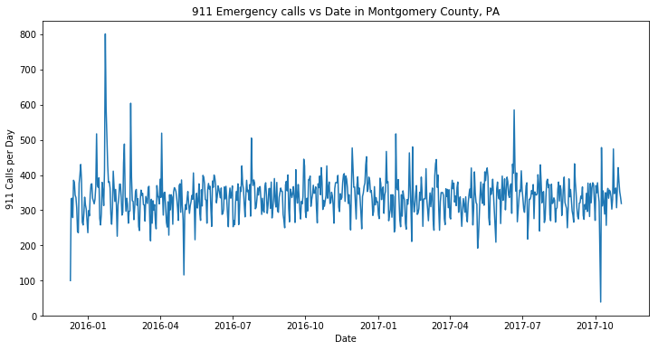

```python
#Plot the data
fig,ax=plt.subplots(figsize=(12,6))
plt.plot_date(data_group_date['date'],data_group_date['Count'],'-')
#Title for the graph and assign x,y axis label
plt.title('911 Emergency calls vs Date in Montgomery County, PA')
plt.xlabel('Date')
plt.ylabel('911 Calls per Day')
plt.show()
```

From the graph, we see that the emergency calls are relatively stable throught out the time from the end of 2015 - 2017. However, we can get more precise information by looking at the mean and standard deviation of the dataset along with the regression line graph. The mean tells us about the average of calls per day, and the standard deviation tells us how much calls per day tend to vary. And lastly, the regression line tells us about the overtrend for number of calls across the time period.

```python
#The mean of the data
print("The mean is " + str(data_group_date['Count'].mean()) +", meaning the average phone calls is ~337")
#The standard deviation of the data
print("The standard deviation is "+str((data_group_date['Count'].std())) + ", meaning the calls per days tend to vary is 56.9")
```

```
The mean is 337.185878963, meaning the average phone calls is ~337
The standard deviation is 56.8753608252, meaning the calls per days tend to vary is 56.9
```

Creating a regression line in order to see the overall trend in the calls throughout years.

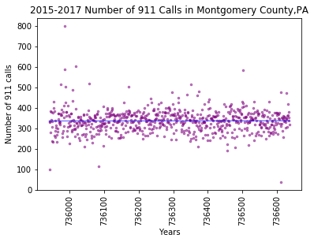

```python
reg = linear_model.LinearRegression()
data_reg = data_group_date.copy()

data_reg['date_ordinal'] = data_reg['date'].apply(lambda x:x.toordinal())
x = data_reg['date_ordinal']
y = data_group_date['Count']
x = np.reshape(x,(-1,1))
y = y.reshape(-1,1)
reg.fit(x,y)
fig,ax = plt.subplots()
ax.plot(x,y,marker='.',linestyle='None',ms=5,color='purple',alpha=.5)
ax.plot(x,reg.predict(x).ravel(),color='blue',alpha=.5)

ax.set_xlabel('Years')
ax.set_ylabel('Number of 911 calls')
ax.set_title("2015-2017 Number of 911 Calls in Montgomery County,PA")
plt.xticks(rotation=90)
plt.show()
plt.close("all")
```

From the linear regression line that sklearn generated, we can see that even though there are a few outliners at the beginning and the end of the graph, the line still have an approximately zero slope. This means that the overall trend for the number of 911 calss has been stable throughout years.

#### 2.3.1.1 Time of day vs number of 911 calls

Because the numbers of call are relatively steady throughout years, we can consider looking at the time of the day. There could be a different rate of phone calls during the day, afternoon, and night time.

The time format right now is HH:MM:SS, but we only need HH. The MM:SS are too small to scale for one full day. We'll lose some specificity but we will have a more readable data.

We'll create another column for hours to the Dataframe.

```python
data_hour = data_df.copy()
#isolate hour from time column
data_hour['hour'] = data_hour.time.apply(lambda x:x.hour)

#group by hour
data_hour_group = data_hour.groupby(data_hour['hour'],as_index=True).count()
#drop the last "hour" column
data_hour_group = data_hour_group.drop('hour',axis=1)
data_hour_group = data_hour_group.reset_index()
#Replace the column name with count and display in order to graph
data_hour_group = data_hour_group.rename(index=str,columns={'time':'count'})
#display the first 5
data_hour_group[['hour','count']].head()
```

|  | hour | count |
| --- | --- | --- |
| 0 | 0 | 4829 |
| 1 | 1 | 4109 |
| 2 | 2 | 3812 |
| 3 | 3 | 3395 |
| 4 | 4 | 3264 |

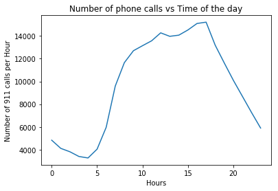

```python
plt.plot(data_hour_group['hour'],data_hour_group['count'])
#name the graph and xlabel and ylabel
plt.title('Number of phone calls vs Time of the day')
plt.xlabel('Hours')
plt.ylabel('Number of 911 calls per Hour')

plt.show()
```

#### 2.3.1.2 Insight about number of phone calls means & deviation

The above graph maps about the total number of calls vs time of the day in general. But what is the average phone calls over time of the day across years. We're trying to get a closer look at how the average day would be like, such as what is the average peak hours for the phone calls.

We will start by group not only the time but also the date.

```python
#group by date and then time based on date
data_datetime_group = data_hour.copy()
data_datetime_group = data_datetime_group.groupby([data_datetime_group['date'],data_datetime_group['hour']],as_index=True).count()
data_datetime_group = data_datetime_group.reset_index()
data_datetime_group = data_datetime_group.rename(index=str,columns={'lat':'count'})

#display only date, hour and count based on those 2 categories
data_datetime_group[['date','hour','count']].head()
```

|  | date | hour | count |
| --- | --- | --- | --- |
| 0 | 2015-12-10 | 14 | 1 |
| 1 | 2015-12-10 | 15 | 1 |
| 2 | 2015-12-10 | 16 | 5 |
| 3 | 2015-12-10 | 17 | 13 |
| 4 | 2015-12-10 | 18 | 18 |

The table above is the count of phone calls at every hour at everyday. Now we will calculate the averay phonecall over days

```python
#average phone calls over days
data_mean_datetime = data_datetime_group.groupby([data_datetime_group['hour']],as_index=True).mean().reset_index()
data_mean_datetime[['hour','count']].head()
```

|  | hour | count |
| --- | --- | --- |
| 0 | 0 | 7.029112 |
| 1 | 1 | 6.007310 |
| 2 | 2 | 5.597651 |
| 3 | 3 | 4.978006 |
| 4 | 4 | 4.764964 |

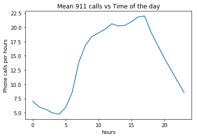

```python
#plot the data
plt.plot(data_mean_datetime['hour'],data_mean_datetime['count'])
#name the title and xlabel,ylabel
plt.title('Mean 911 calls vs Time of the day')
plt.xlabel('hours')
plt.ylabel('Phone calls per hours')
plt.show()
```

Now let's look at the standard deviation across days of 911 calls.

```python
data_std_datetime = data_datetime_group.groupby([data_datetime_group['hour']],as_index=True).std().reset_index()
data_std_datetime[['hour','count']].head()
```

|  | hour | count |
| --- | --- | --- |
| 0 | 0 | 3.233710 |
| 1 | 1 | 2.931368 |
| 2 | 2 | 2.923977 |
| 3 | 3 | 2.503058 |
| 4 | 4 | 2.521591 |

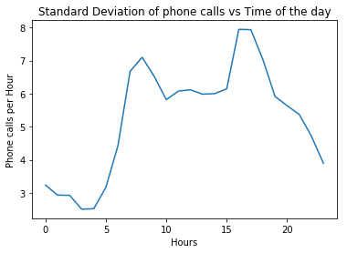

```python
#plot the standard deviation
plt.plot(data_std_datetime['hour'],data_std_datetime['count'])
plt.title('Standard Deviation of phone calls vs Time of the day')
plt.ylabel('Phone calls per Hour')
plt.xlabel('Hours')
plt.show()
```

### 2.3.2 Phone calls factor

First, we will look at the factor that causing the emergency calls. Fators is 'title' columns in the table. There are 3 main groups: EMS, Fire, Traffic

```python
data_factor = data_hour.copy()
data_factor['type'] = data_factor['title'].apply(lambda x: x.split(':')[0])

#display the number of phone calls based on factors
data_factor['type'].value_counts()
```

```
EMS        121251
Traffic     77771
Fire        34985
Name: type, dtype: int64
```

We will now look closer to how phone calls spread across hours throughout the date

```python
data_factor = data_factor.groupby([data_factor['hour'],data_factor['type']]).count()
data_factor = data_factor.drop('hour',axis=1)
data_factor = data_factor.rename(index=str,columns={'lat':'count'})
data_factor[['count']].head()
```

| hour | type | count |
| --- | --- | --- |
| 0 | EMS | 3140 |
|  | Fire | 706 |
|  | Traffic | 983 |
| 1 | EMS | 2760 |
|  | Fire | 613 |

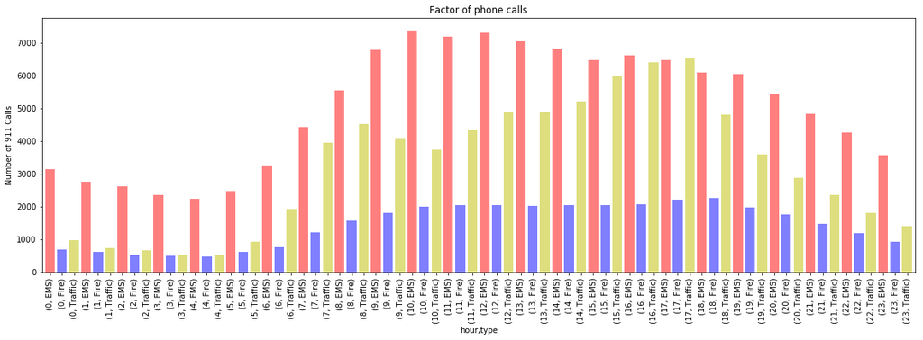

```python
#plot the number of type vs time of the day
fig, ax = plt.subplots(1,figsize=(20,6))
ax.set_xlabel('Hour')
ax.set_ylabel('Number of 911 Calls')
ax.set_title('Factor of phone calls')

df = pd.DataFrame(columns=['EMS','Fire','Traffic'],data = data_factor)
data_factor['count'].plot.bar(ax=ax,color=['r','b','y'],alpha =0.5,width = 0.8)

plt.show()
```

In the graph, traffic tends to increase during rush hours, people come home from work, creating traffic jam and other things.

## 3/ Machine learning

We want to predict number of phone calls by hours. So we will use numpy polyfit totrain a polynomial fit for those 2 y and x values.

Numpy polynomial will train on a set of x and y points and a degree n. It fit a polynomial p(x) = p[0] *x* deg +.....+ p[deg] of degree deg to points(x,y). It returns a vector of coefficients p that minimises the squared error. For more information, you can find at https://docs.scipy.org/doc/numpy-1.13.0/reference/generated/numpy.polyfit.html

```python
#randomly shuffle the data
data_ex = data_datetime_group.copy().sample(frac=1)
cut = int(len(data_ex)*2/3)
```

```python
#split the data into training and testing
data_test = data_ex[cut::]
data_train = data_ex[0::cut]

#display
data_test.head()
```

|  | date | hour | count | lng | desc | zip | title | timeStamp | twp | addr | e | time | year |
| --- | --- | --- | --- | --- | --- | --- | --- | --- | --- | --- | --- | --- | --- |
| 1630 | 2016-02-17 | 4 | 2 | 2 | 2 | 2 | 2 | 2 | 2 | 2 | 2 | 2 | 2 |
| 14968 | 2017-08-28 | 0 | 8 | 8 | 8 | 8 | 8 | 8 | 8 | 8 | 8 | 8 | 8 |
| 3545 | 2016-05-07 | 19 | 19 | 19 | 19 | 19 | 19 | 19 | 19 | 19 | 19 | 19 | 19 |
| 16145 | 2017-10-17 | 23 | 10 | 10 | 10 | 10 | 10 | 10 | 10 | 10 | 10 | 10 | 10 |
| 6859 | 2016-09-23 | 3 | 5 | 5 | 5 | 5 | 5 | 5 | 5 | 5 | 5 | 5 | 5 |

```python
data_train.head()
```

|  | date | hour | count | lng | desc | zip | title | timeStamp | twp | addr | e | time | year |
| --- | --- | --- | --- | --- | --- | --- | --- | --- | --- | --- | --- | --- | --- |
| 9592 | 2017-01-15 | 6 | 11 | 11 | 11 | 11 | 11 | 11 | 11 | 11 | 11 | 11 | 11 |
| 1630 | 2016-02-17 | 4 | 2 | 2 | 2 | 2 | 2 | 2 | 2 | 2 | 2 | 2 | 2 |

```python
x_train = data_train['hour']
y_train = data_train['count']

#predict
predict = np.polyfit(x_train,y_train,11)
final_poly = np.poly1d(predict)
```

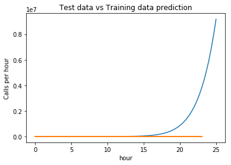

```python
#test data
x_test = data_test['hour']
y_test=data_test['count']

predict_x = np.linspace(0,25,100)
predict_y = final_poly(predict_x)

plt.plot(predict_x,predict_y)
plt.plot(x_test,y_test)

plt.title('Test data vs Training data prediction')
plt.ylabel('Calls per hour')
plt.xlabel('hour')
plt.show()
```

# Summary and References

Knowing about the peak time for 911 calls can lead to lots of study behind it. Also, it can let both the emergency ambulance as well as hospital as well as police to get ready for those phone calls.

The dataset is very rich in information, we have not consider the location factor such as lat, long, township. We want reader to look more into different aspect of the dataset and try it themselves.

References: Matplotlib http://matplotlib.org/contents.html

Regex https://docs.python.org/2/library/re.html

Polyfit https://docs.scipy.org/doc/numpy/reference/generated/numpy.polyfit.html

Scikit-learn http://scikit-learn.org/stable/

Anaconda https://www.continuum.io

Pandas http://pandas.pydata.org

Cheat Sheet https://www.dataquest.io/blog/images/cheat-sheets/pandas-cheat-sheet.pdf

Groupby http://pandas.pydata.org/pandas-docs/stable/generated/pandas.DataFrame.groupby.html

Data sources: https://www.kaggle.com/mchirico/montcoalert